# Moneyball

Jorge Ferreira

To tackle this challenge, we are provided with two datasets: players historical stats and salaries. Let’s take a look at them.

```r
library(readr)
batting <- read.csv('~/Desktop/Moneyball/Batting.csv')
head(batting)
```

```
##    playerID yearID stint teamID lgID  G G_batting AB R H X2B X3B HR RBI SB
## 1 aardsda01   2004     1    SFN   NL 11        11  0 0 0   0   0  0   0  0
## 2 aardsda01   2006     1    CHN   NL 45        43  2 0 0   0   0  0   0  0
## 3 aardsda01   2007     1    CHA   AL 25         2  0 0 0   0   0  0   0  0
## 4 aardsda01   2008     1    BOS   AL 47         5  1 0 0   0   0  0   0  0
## 5 aardsda01   2009     1    SEA   AL 73         3  0 0 0   0   0  0   0  0
## 6 aardsda01   2010     1    SEA   AL 53         4  0 0 0   0   0  0   0  0
##   CS BB SO IBB HBP SH SF GIDP G_old
## 1  0  0  0   0   0  0  0    0    11
## 2  0  0  0   0   0  1  0    0    45
## 3  0  0  0   0   0  0  0    0     2
## 4  0  0  1   0   0  0  0    0     5
## 5  0  0  0   0   0  0  0    0    NA
## 6  0  0  0   0   0  0  0    0    NA
```

```r
salaries <- read.csv('~/Desktop/Moneyball/Salaries.csv')
head(salaries)
```

```
##   yearID teamID lgID  playerID  salary
## 1   1985    BAL   AL murraed02 1472819
## 2   1985    BAL   AL  lynnfr01 1090000
## 3   1985    BAL   AL ripkeca01  800000
## 4   1985    BAL   AL  lacyle01  725000
## 5   1985    BAL   AL flanami01  641667
## 6   1985    BAL   AL boddimi01  625000
```

There are plenty of metrics that help us analysing players’ performance but we will be focusing on a few of them only, whicih we still need to calculate:

- [Batting Average](https://en.wikipedia.org/wiki/Batting_average)
- [On Base Percentage](https://en.wikipedia.org/wiki/On-base_percentage)
- [Slugging Percentage](https://en.wikipedia.org/wiki/Slugging_percentage)

```r
# Batting Average
batting$BA <- batting$H / batting$AB

# On Base Percentage
batting$OBP <- (batting$H + batting$BB + batting$HBP)/(batting$AB + batting$BB + batting$HBP + batting$SF)

# Creating X1B (Singles) for Slugging Percentage calculation
batting$X1B <- batting$H - batting$X2B - batting$X3B - batting$HR

# Slugging Average (SLG)
batting$SLG <- ((1 * batting$X1B) + (2 * batting$X2B) + (3 * batting$X3B) + (4 * batting$HR) ) / batting$AB
```

In 2001, we lost Giambja01, Damonjo01 and Saenzol01, who were at the peak of their performance.

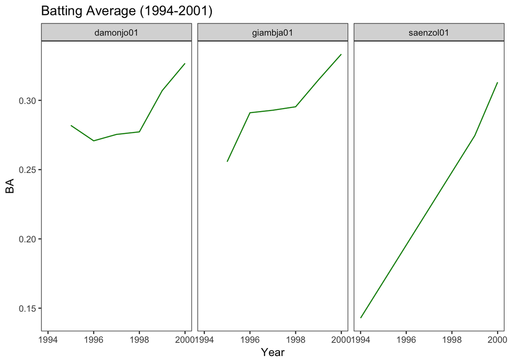

```r
library(ggplot2)
library(ggExtra)
GDS <- subset(batting,playerID %in% c('giambja01','damonjo01','saenzol01'))
ggplot(data=GDS[GDS$yearID<2001,], aes(x=yearID, y=BA, group=1)) +
  geom_line(stat="identity", color="green4") + xlab("Year") + facet_grid(~playerID) + theme_bw() + removeGrid() + ggtitle("Batting Average (1994-2001)")
```

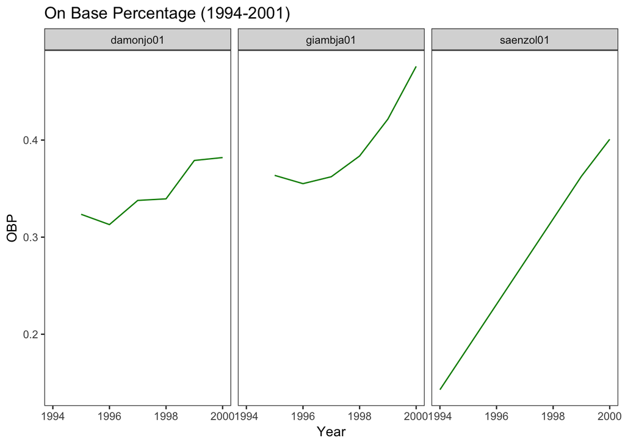

```r
ggplot(data=GDS[GDS$yearID<2001,], aes(x=yearID, y=OBP, group=1)) +
  geom_line(stat="identity", color="green4") + xlab("Year") + facet_grid(~playerID) + theme_bw() + removeGrid() + ggtitle("On Base Percentage (1994-2001)")
```

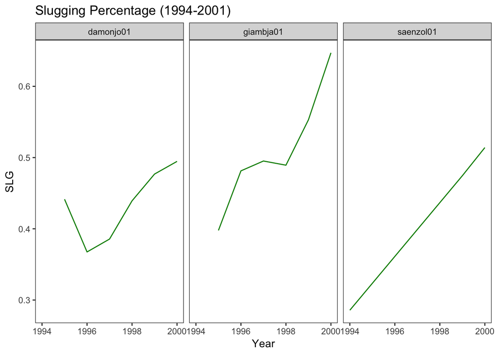

```r
ggplot(data=GDS[GDS$yearID<2001,], aes(x=yearID, y=SLG, group=1)) +
  geom_line(stat="identity", color="green4") + xlab("Year") + facet_grid(~playerID) + theme_bw() + removeGrid() + ggtitle("Slugging Percentage (1994-2001)")
```

As salary is a key condition in our quest for potential players, is useful to merge both datasets.

```r
data <- merge(batting,salaries,by=c('playerID','yearID'))
```

Although we have data since 1985, we only care about the year of 2001.

```r
data <- subset(data, data$yearID==2001)
```

How are these players performing?

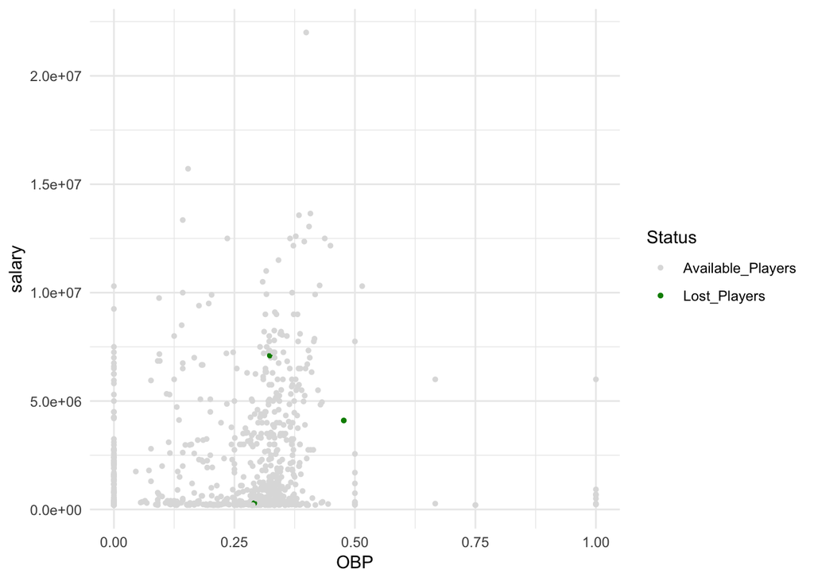

```r
data$lost_players <- ifelse(data$playerID == "giambja01" | data$playerID == "damonjo01" | data$playerID == "saenzol01", "Lost_Players", "Available_Players")
mycolors         <- c("Lost_Players" = "green4", "Available_Players" = "grey87")

ggplot(data = data, aes(x = OBP, y = salary)) +
  geom_point(size = 1, aes(colour = lost_players)) +
  scale_color_manual("Status", values = mycolors) + theme_minimal()
```

In green we can see our lost players and in grey the ones we have available on the market. Let’s see how the players we lost performed that season

```r
lost_players <- subset(data,playerID %in% c('giambja01','damonjo01','saenzol01'))
lost_players <- lost_players[,c('playerID','H','X2B','X3B','HR','OBP','SLG','BA','AB')]
head(lost_players)
```

```
##        playerID   H X2B X3B HR       OBP       SLG        BA  AB
## 5141  damonjo01 165  34   4  9 0.3235294 0.3633540 0.2562112 644
## 7878  giambja01 178  47   2 38 0.4769001 0.6596154 0.3423077 520
## 20114 saenzol01  67  21   1  9 0.2911765 0.3836066 0.2196721 305
```

We have a lot of players who have 0% of OBP. It might mean that they haven’t had the chance to show their skills as they haven’t played yet. The same rational for 100% OBP, meaning they might have played once and were lucky enough to perform too well.

Now we have to find replacement players for the key three players we lost! However, you have three constraints:

- The total combined salary of the three players can not exceed 15 million dollars.
- Their combined number of At Bats (AB) needs to be equal to or greater than the lost players.
- Their mean OBP had to equal or be greater than the mean OBP of the lost players

So, am going to highlight potential players who we can consider:

- Will set our max salary at 8M$
- OBP should be higher than 0.3638687
- Will look at the ones whose AB is around 500 (1469/3)

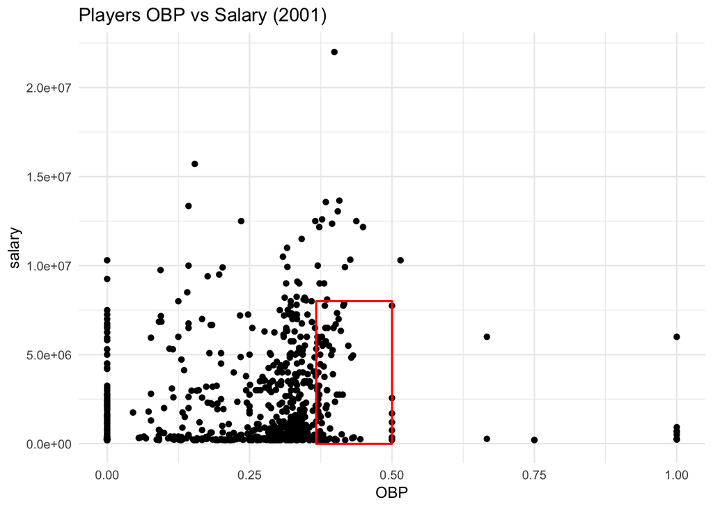

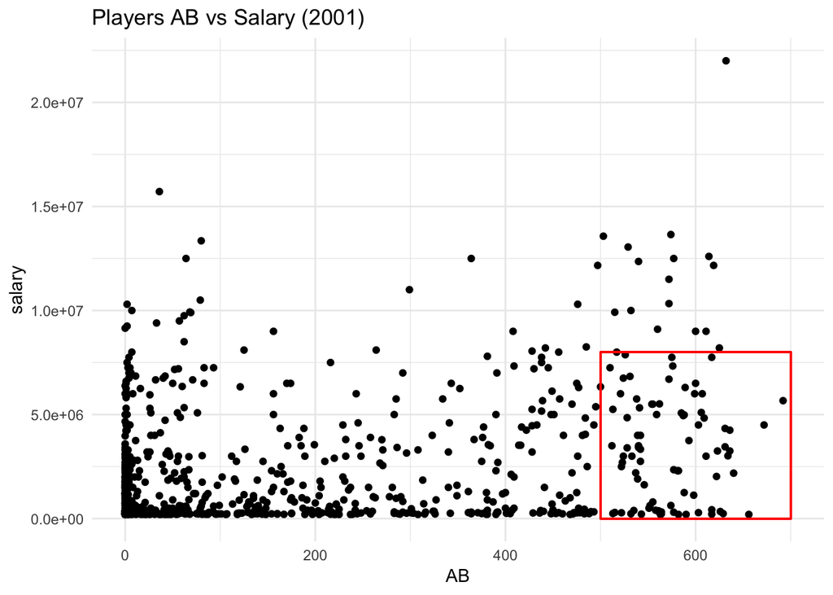

```r
avail.players <- subset(data, !(playerID %in% c('giambja01','damonjo01','saenzol01')))
#OBP vs Salary
ggplot(avail.players,aes(x=OBP,y=salary)) + geom_point() + geom_rect(data=avail.players, mapping=aes(xmin=0.367, xmax=0.5, ymin=0, ymax=8000000), color="red", alpha=0) + theme_minimal() + ggtitle("Players OBP vs Salary (2001)")
#Aggregate AB should be above 1469, so let's set individual AB at around 500.
ggplot(avail.players,aes(x=AB,y=salary)) + geom_point() + ggtitle("Players AB vs Salary (2001)") + geom_rect(data=avail.players, mapping=aes(xmin=500, xmax=700, ymin=0, ymax=8000000), color="red", alpha=0) + theme_minimal()
```

By filtering these players and sorting them, we can make a decision who to sign in next:

```r
library(dplyr)
potential_players <- subset(avail.players, salary<8000000 & OBP>0.367 & AB>500)
potential_players_resume <- potential_players[,c('playerID','OBP','AB','salary','BA','SLG')]
head(arrange(potential_players_resume,desc(OBP),desc(AB),desc(BA),desc(SLG),salary),10)
```

```
##     playerID       OBP  AB  salary        BA       SLG
## 1  heltoto01 0.4316547 587 4950000 0.3356048 0.6848382
## 2  berkmla01 0.4302326 577  305000 0.3310225 0.6204506
## 3  gonzalu01 0.4285714 609 4833333 0.3251232 0.6880131
## 4  thomeji01 0.4161491 526 7875000 0.2908745 0.6235741
## 5  alomaro01 0.4146707 575 7750000 0.3356522 0.5408696
## 6  gilesbr02 0.4035608 576 7333333 0.3090278 0.5902778
## 7  pujolal01 0.4029630 590  200000 0.3288136 0.6101695
## 8  olerujo01 0.4011799 572 6700000 0.3024476 0.4720280
## 9  bagweje01 0.3974895 600 6500000 0.2883333 0.5683333
## 10  aloumo01 0.3958692 513 5250000 0.3313840 0.5536062
```

I would chose Heltoto01, Berkmla01 and Gonzalu01!